# R Training

## `.csv` files

The `.csv` is such an important file type when you work with data that it is worth introducing it with more detail.

When you preview a `.csv`, it looks something like this:

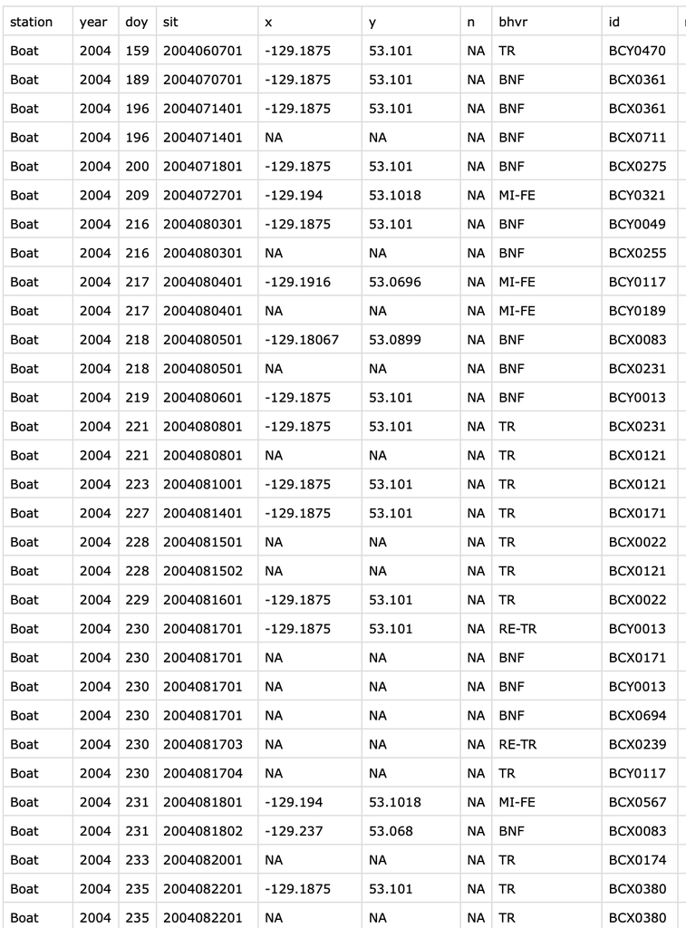

A neat spreadsheet of rows and columns.

When you open up this same dataset in a simple text editor, it looks like this:

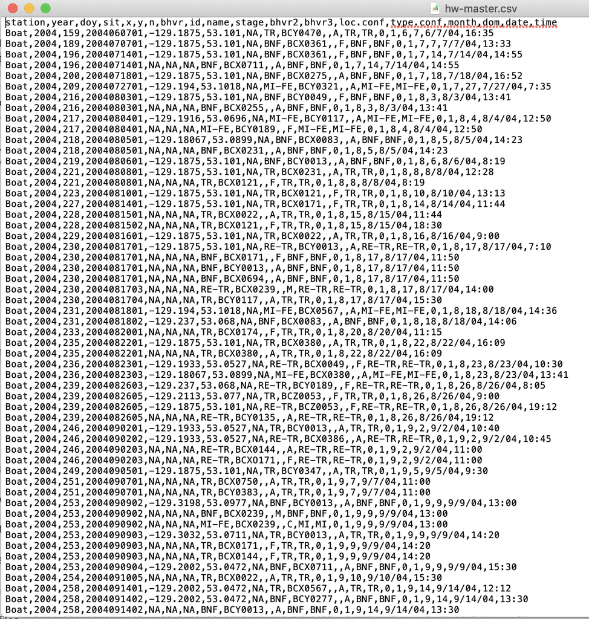

This looks scary, but it is actually really simple. A `.csv` is a simple text file in which each row is on a new line and columns of data are separated by commas. As a simple text file, there is no fancy formatting. There are no “Sheets” or “Tabs”, as you would find in GoogleSheets or Excel; it is a simple ‘flat’ file.

One of the major advantages of working with `.csv`’s is that the format is cross-platform and non-proprietary. That is, they work on Windows, Mac, Linux, and any other common type of computer, and they do not require special software to open.

## Prepping your data for `R`

For those of us used to working in *Excel*, *GoogleSheets*, or *Numbers*, it will take some adjustment to get into the habit of formatting your data for `R`. We are used to seeing spreadsheets that look something like this:

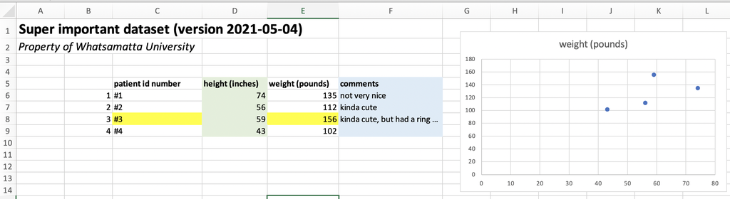

To read a `.csv` into `R` without issues or fancy code, this spreadsheet will need to be simplified to look like this:

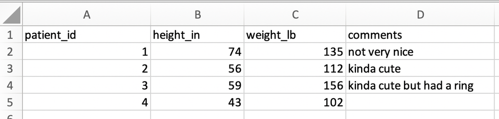

### Workflow for formatting your data

Below is the general worfklow for preparing your data for `R` is the following:

**1. Get your data into `.csv` format.** In *Excel* and *Numbers*, you can use ‘Save As’ to change the file format. In *GoogleSheets*, you can ‘Download As’ a `.csv`. This will remove any colors, thick lines, special fonts, bold or italicized font styles, and any other special formatting. All that will be left is your data, and that’s the way `R` likes it.

**2. Remove blank columns** before and in the middle of your data.

**3. Remove fancy elements such as graphs.**

**4. Simplify your ‘header’.** The space above your data is your spreadsheet’s header. It includes column names and metadata like title, author, measurement units, etc. It is possible to read data with complex headers into `R`, but again we are going for simplicity here, so we suggest (1) simplifying your header to contain column names only, and (2) moving metadata to a `README.txt` file that lives in the same folder as your data.

**5. Simplify column names.** Remove spaces, or replace them with `.`, `-` or `_`. Make your column names as simple and brief as possible while still being informative. Include units in the column names, as in the screenshot above. Be sure that each column has a name.

**6. Remove all commas and hashtags from your dataset.** You can do this with the ‘Find & Replace’ feature built-into in most spreadsheet editors.

## Managing files & folders

### Reading data from other folders

```r
df <- read.csv("data/super_data.csv")
```

Sometimes, though, you will want to keep your data somewhere nearby but not necessarily *within* your working directory. Consider the following scenario, in which three versions of the “super_data.csv” dataset occur near a working directory being used for this module:

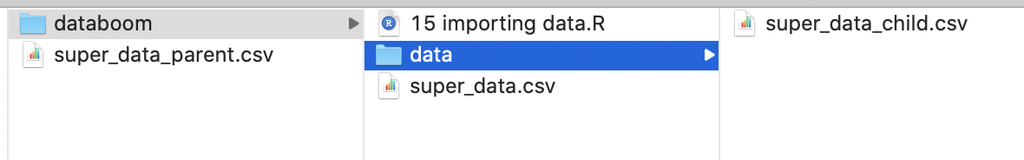

We have a version within the same directory as our `R` file (i.e., our working directory), another version within a *child* folder within the directory (i.e., a subfolder), and another version in the *parent* folder of the working directory.

**To read a file from a *child* folder,** add the prefix, `./<child name>/`, to your command:

```r
df <- read.csv("./data/super_data.csv")
```

```r
df <- read.csv("./data/super_data.csv")
```

### Managing files

Now consider the following scenario, in which your project folder structure looks like this:

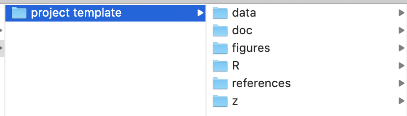

This structure can be a effective and simple way of organizing your files for a project, and we recommend using it.

Here’s what these child folders should contain.

- `./data/` contains data, of course.
- `./doc/` contains documents, such as manuscript drafts.
- `./figures/` contains files for graphs and figures.
- `./R/` contains `R` scripts, of course.
- `./references/` contains journal articles and other resources you are using in your research.

Since your `R` code is going into the `R` child folder, that is what you should set your working directory for those `R` scripts to. In that case, *how to read data from the `data` folder*, which is a separate child folder of your parent folder?

Here’s how:

```r
df <- read.csv("../data/super_data.csv")
```

# 15 Base plots

#### Learning goals

- Make basic plots in `R`
- Basic adjustments to plot formatting

To learn how to plot, let’s first create a dataset to work with:

```r
country <- c("USA","Tanzania","Japan","Ctr. Africa Rep.","China","Norway","India")
lifespan <- c(79,65,84,53,77,82,69)
gdp <- c(55335,2875,38674,623,13102,84500,6807)
```

These data come from this [publicly available database](https://datasets.iisg.amsterdam/dataset.xhtml?persistentId=hdl:10622/LKYT53) that compares health and economic indices across countries in 2011.

The `lifespan` column presents the average life expectancy for each country.

The `gdp` column presents the average GDP per capita within that country, which is a common index for the income and wealth of average citizens.

Let’s see if there is a relationship between life expectancy and income.

## Create a basic plot

The simplest way to make a basic plot in `R` is to use its built-in `plot()` function:

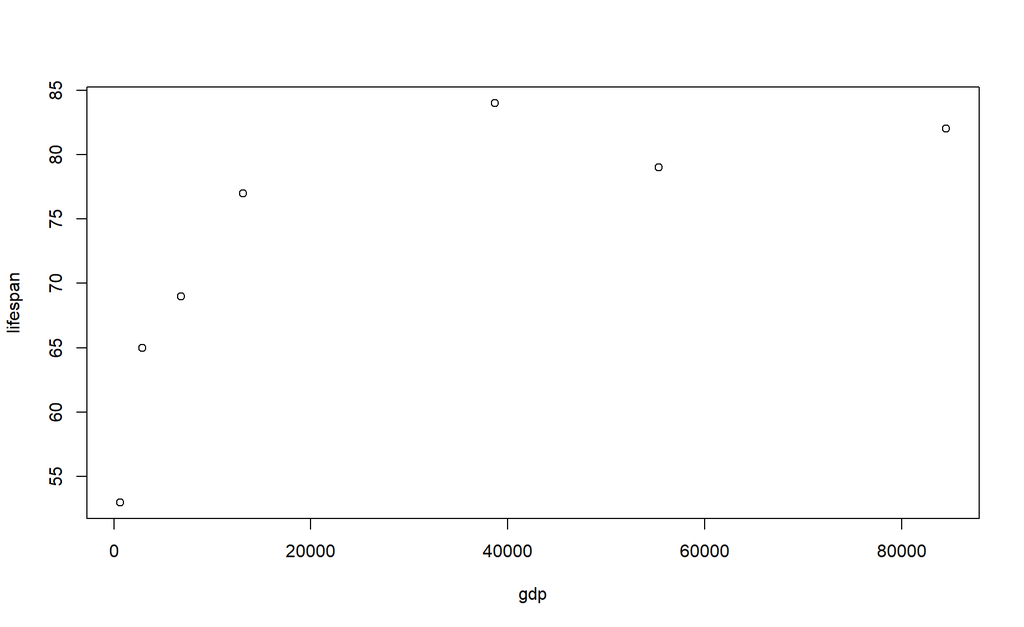

```r
plot(lifespan ~ gdp)
```

This syntax is saying this: plot column `lifespan` as a function of `gdp`. The symbol `~` denotes *“as a function of”*. This frames `lifespan` as a dependent variable (y axis) that is affected by the independent variable (x axis), which in this case is `gdp`.

Note that `R` uses the variable names you provided as the x- and y-axes. You can adjust these labels however you wish (see formatting section below).

You can also produce this exact same plot using the following syntax:

```r
plot(y=lifespan, x=gdp)
```

Choose whichever one is most intuitive to you.

## Most common types of plots

The plot above is a **scatter plot**, and is one of the most common types of plots in data science.

You can turn this into a **line plot** by adding a parameter to the `plot()` function:

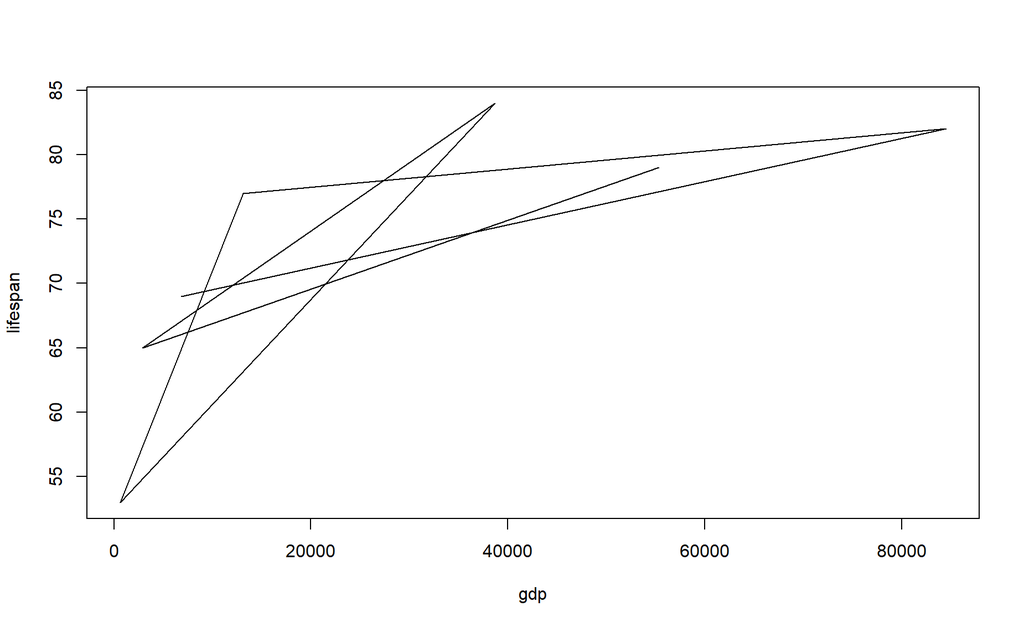

```r
plot(lifespan ~ gdp, type="l")
```

*What a mess!* Rather than connecting these values in the order you might expect, `R` connects them in the order that they are listed in their source vectors. This is why line plots tend to be more useful in scenarios such as time series, which are inherently ordered.

Another common plot is the **bar plot**, which uses a different `R` function:

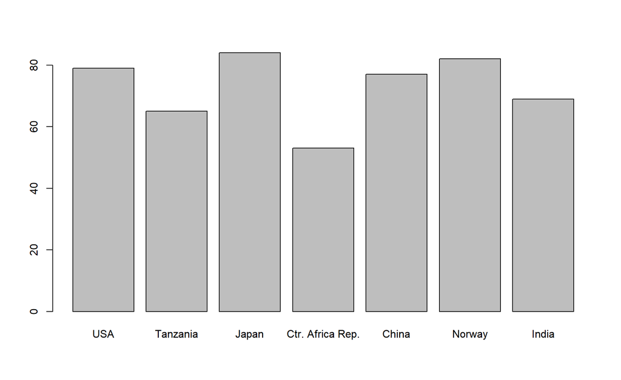

```r
barplot(height=lifespan,names.arg=country)
```

In this command, the parameter `height` determines the height of the bars, and `names.arg` provides the labels to place beneath each bar.

There are many more plot types out there, but let’s stop here for now.

## Basic plot formatting

You can adjust the default formatting of plots by adding other inputs to your `plot()` command. To understand all the parameters you can adjust, bring up the help page for this function:

```r
?plot
```

If multiple help page options are returned, select the *Generiz X-Y Plotting* page from the `base` package. This is the plot function that comes built-in to `R`.

Here we demonstrate just a few of the most common formatting adjustments you are likely to use:

**Set plot range** using `xlim` (for the x axis) and `ylim` (for the y axis):

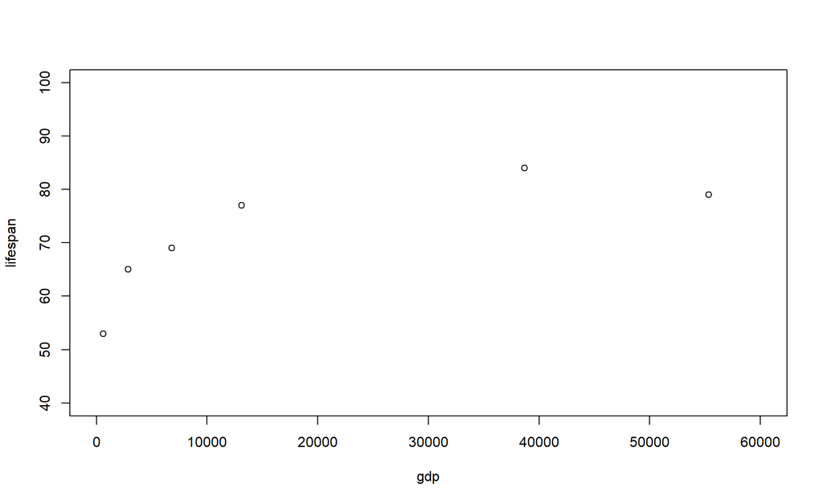

```r
plot(lifespan ~ gdp,xlim=c(0,60000),ylim=c(40,100))
```

In this command, you are defining axis limits using a 2-element vector (i.e., `c(min,max)`).

Note that it can be easier to read your code if you put each input on a new line, like this:

```r
plot(lifespan ~ gdp,
     xlim=c(0,60000),
     ylim=c(40,100))
```

Make sure each input line within the function ends with a comma, otherwise you `R` will get confused and throw an error.

**Set dot type** using the input `pch`:

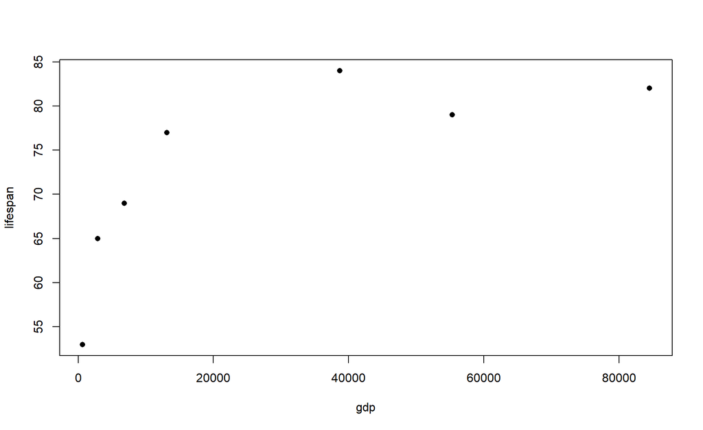

```r
plot(lifespan ~ gdp,pch=16)
```

**Set dot color** using the input `col` (the default is `col="black"`)

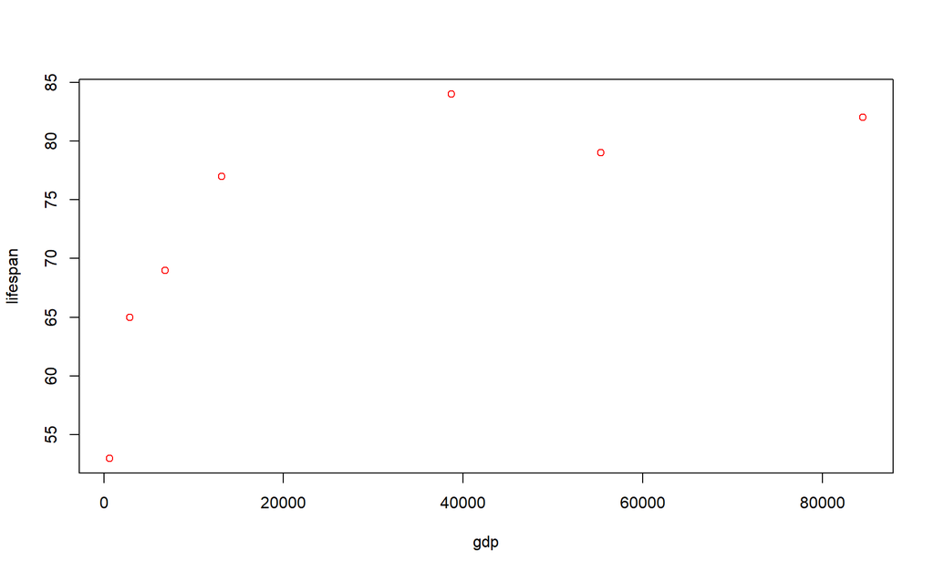

```r
plot(lifespan ~ gdp,col="red")
```

[Here is a great resource](http://www.stat.columbia.edu/~tzheng/files/Rcolor.pdf?utm_source=twitterfeed&utm_medium=twitter) for color names in `R`.

**Set dot size** using the input `cex` (the default is `cex=1`):

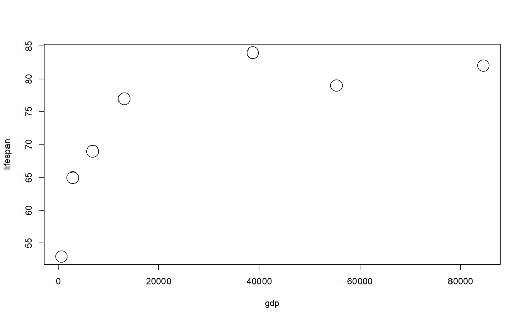

```r
plot(lifespan ~ gdp,cex=3)
```

**Set axis labels** using the inputs `xlab` and `ylab`:

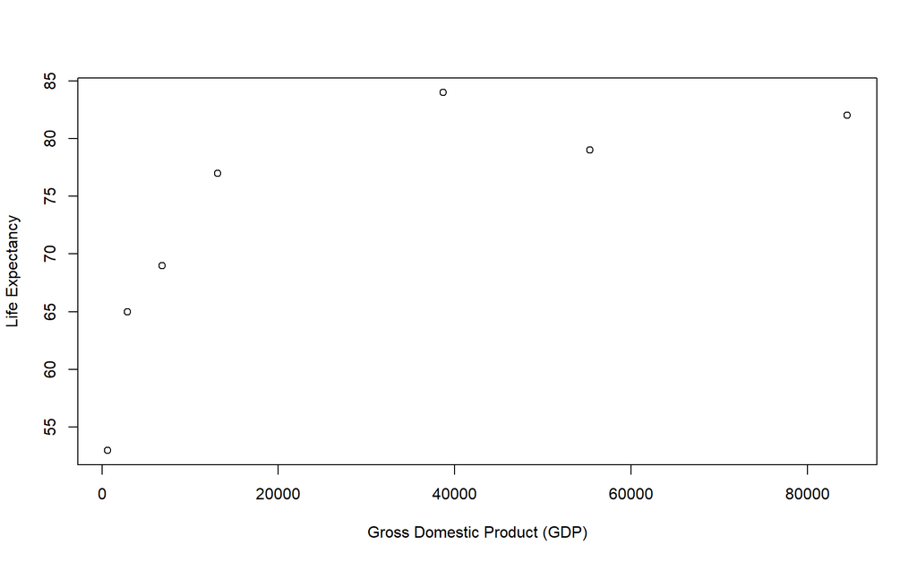

```r
plot(lifespan ~ gdp, xlab="Gross Domestic Product (GDP)",ylab="Life Expectancy")
```

**Set axis number size** using the input `cex.axis` (the default is `cex.axis=1`):

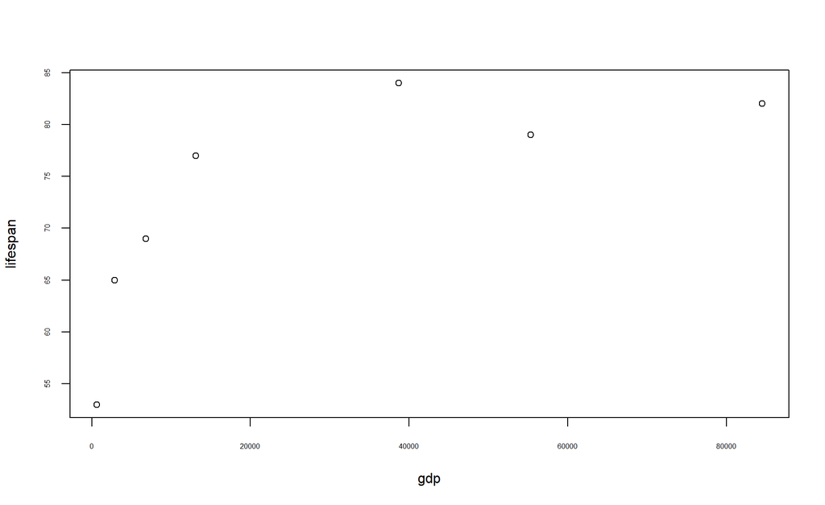

```r
plot(lifespan ~ gdp,cex.axis=.5)
```

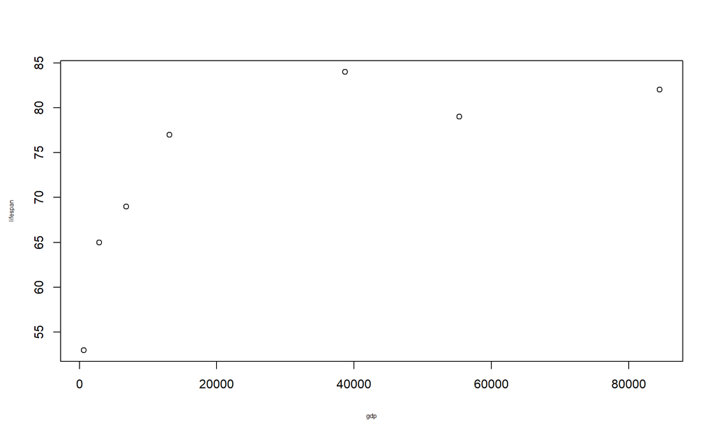

```r
plot(lifespan ~ gdp,cex.lab=.5)
```

**Set plot margins** using the function `par(mar=c())` before you call `plot()`:

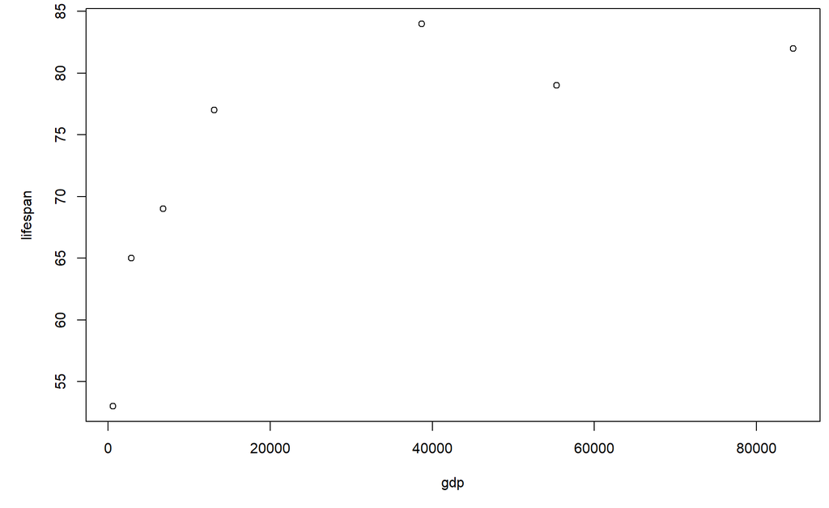

```r
par(mar=c(5,5,0.5,0.5))
plot(lifespan ~ gdp)
```

In this command, the four numbers in the vector used to define `mar` correspond to the margin for the bottom, left, top, and right sides of the plot, respectively.